# Programación conjunta en R y Python con reticulate (usando un fichero R Markdown)

Aplicación 0.2.a: Ejemplos en interoperabilidad entre R y Python usando RStudio

Julián Ramajo, ramajo@unex.es

GRADO EN ESTADÍSTICA | ECONOMETRIA (502243)

# 0. Justificación

En este documento se demuestra cómo los ficheros **R Markdown** (con extensión *Rmd*) son un buen entorno para codificar un proyecto simultáneamente en los dos lenguajes de programación más usados en *Data Science*, **R** y **Python**, permitiendo programar algunos elementos del proyecto en cada lenguaje y manipular objetos creados en un lenguaje usando el otro, y viceversa.

Esto puede ser útil por varias razones:

1. Permite codificar en la *lengua nativa en estadística* (**R**) pero añadiendo características que podrían existir sólo en la *segunda lengua* (**Python**); o al contrario. Obviamente cuando uso la palabra *lengua* me refiero a *lenguaje de programación*.
2. Permite colaborar directamente con otro colega que sea un experto programador en el otro lenguaje (**equipos multi-lenguaje**).
3. Da la oportunidad de trabajar en ambos lenguajes de programación y de adquirir fluidez en ellos, intentando alcanzar a largo plazo el *bilingüismo*.

# 1. ¿Qué se necesita?

Para que la interacción R-Python funcione correctametne se necesita lo siguiente:

1. **R** y **Python (miniconda)** instalados en el ordenador.
2. El entorno de ejecución (IDE) **RStudio** también instalado.
3. Las **librerías** `rmarkdown` y `reticulate` instaladas en R.

Trabajaremos en el IDE de RStudio escribiendo en un documento R Markdown, moviéndonos entre trozos de código que están escritos en R o en Python. Haré una demostración con un par de ejemplos sencillos.

# 2. Primer ejemplo

Se puede configurar un documento **R Markdown** y codificar en los dos idiomas diferentes. Primero hay que cargar la librería `reticulate` en el primer trozo de código.

```r
library(reticulate)
```

Ahora, cuando se quiera escribir código en Python, se debe envolver con los habituales signos de puntuación, pero etiquetarlo como un trozo de código python usando `{python}`; y cuando se quieras escribir en R debe usarse `{r}`.

En nuestro primer ejemplo, vamos a suponer que se va a estimar con Python un modelo con un conjunto de datos sobre los resultados finales de las pruebas de los estudiantes en función de sus resultados pasados.

Debajo se ejecuta Python dentro de este código para estimar el modelo:

```python
import pandas as pd
import statsmodels.formula.api as smf

# Datos
url = "http://peopleanalytics-regression-book.org/data/ugtests.csv"
ugtests = pd.read_csv(url)

# Modelo
model = smf.ols(formula = "Final ~ Yr3 + Yr2 + Yr1", data = ugtests)

# Estimación del modelo y resultados
fitted_model = model.fit()
model_summary = fitted_model.summary()
print(model_summary)
```

```
##                             OLS Regression Results
## ==============================================================================
## Dep. Variable:                  Final   R-squared:                       0.530
## Model:                            OLS   Adj. R-squared:                  0.529
## Method:                 Least Squares   F-statistic:                     365.5
## Date:                vie, 10 sep 2021   Prob (F-statistic):          8.22e-159
## Time:                        07:39:30   Log-Likelihood:                -4711.6
## No. Observations:                 975   AIC:                             9431.
## Df Residuals:                     971   BIC:                             9451.
## Df Model:                           3
## Covariance Type:            nonrobust
## ==============================================================================
##                  coef    std err          t      P>|t|      [0.025      0.975]
## ------------------------------------------------------------------------------
## Intercept     14.1460      5.480      2.581      0.010       3.392      24.900
## Yr3            0.8657      0.029     29.710      0.000       0.809       0.923
## Yr2            0.4313      0.033     13.267      0.000       0.367       0.495
## Yr1            0.0760      0.065      1.163      0.245      -0.052       0.204
## ==============================================================================
## Omnibus:                        0.762   Durbin-Watson:                   2.006
## Prob(Omnibus):                  0.683   Jarque-Bera (JB):                0.795
## Skew:                           0.067   Prob(JB):                        0.672
## Kurtosis:                       2.961   Cond. No.                         858.
## ==============================================================================
##
## Notes:
## [1] Standard Errors assume that the covariance matrix of the errors is correctly specified.
```

En este momento has tenido que dejar este trabajo debido a algo más urgente y se lo has pasado a otro colega que sólo programa en R para hacer algunos diagnósticos del modelo.

Pues bien, el nuevo programador puede acceder a todos los objetos python que has creado anteriormente dentro de una lista general llamada `py` en el entorno R.

Así, si escribe un cógigo R como el que sigue puede acceder a los parámetros de tu modelo:

```r
py$fitted_model$params
```

```
##   Intercept         Yr3         Yr2         Yr1
## 14.14598945  0.86568123  0.43128539  0.07602621
```

o a los primeros *residuos* (errores estimados) del mismo, junto con unas estadístias básicas y un histograma:

```r
head(py$fitted_model$resid)
```

```
##        0          1          2          3          4          5
##  10.221609  33.602660  15.154207 -23.022416  -1.778262 -17.317127
```

```r
summary(py$fitted_model$resid)
```

```
##      Min.   1st Qu.    Median      Mean   3rd Qu.      Max.
## -92.63812 -20.34864   0.00081   0.00000  18.95411  98.48933
```

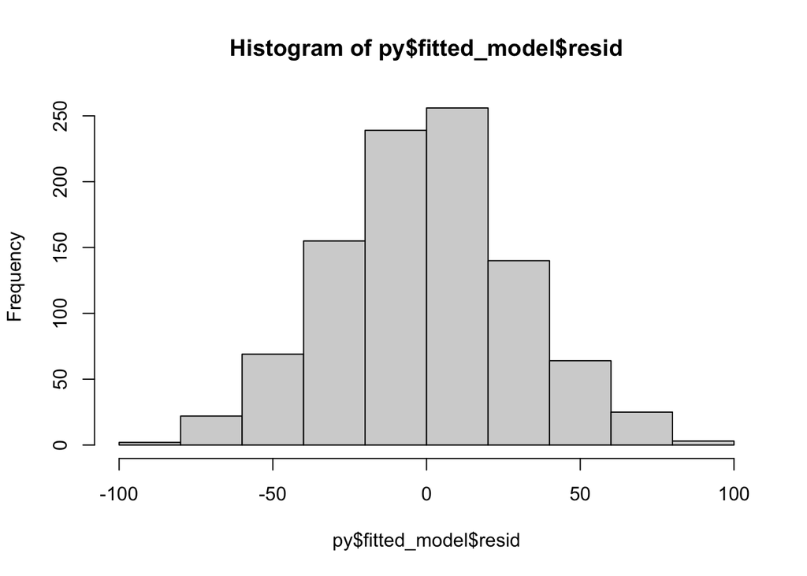

```r
hist(py$fitted_model$resid)
```

Además, se pueden hacer fácilmente algunos **diagnósticos del modelo estimado**:

```r
library(car)
```

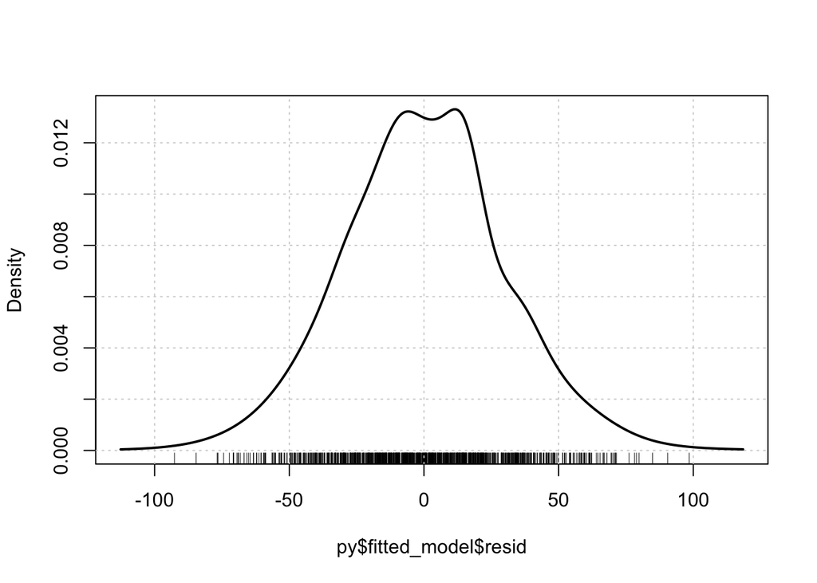

```r
densityPlot(py$fitted_model$resid)
```

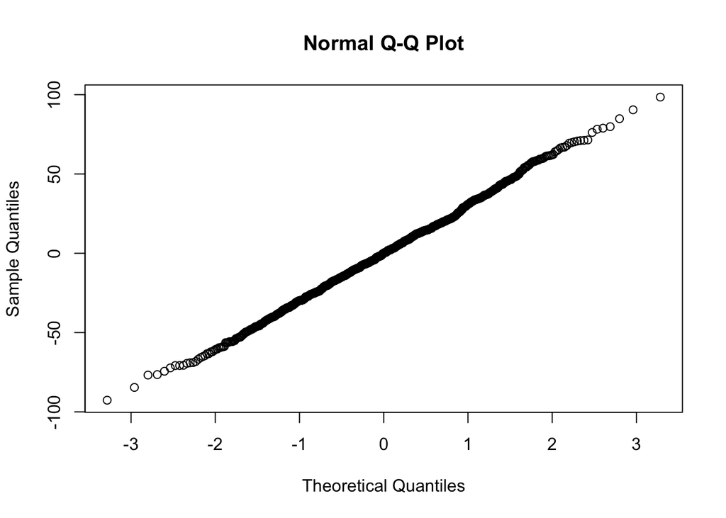

```r
qqnorm(py$fitted_model$resid)
```

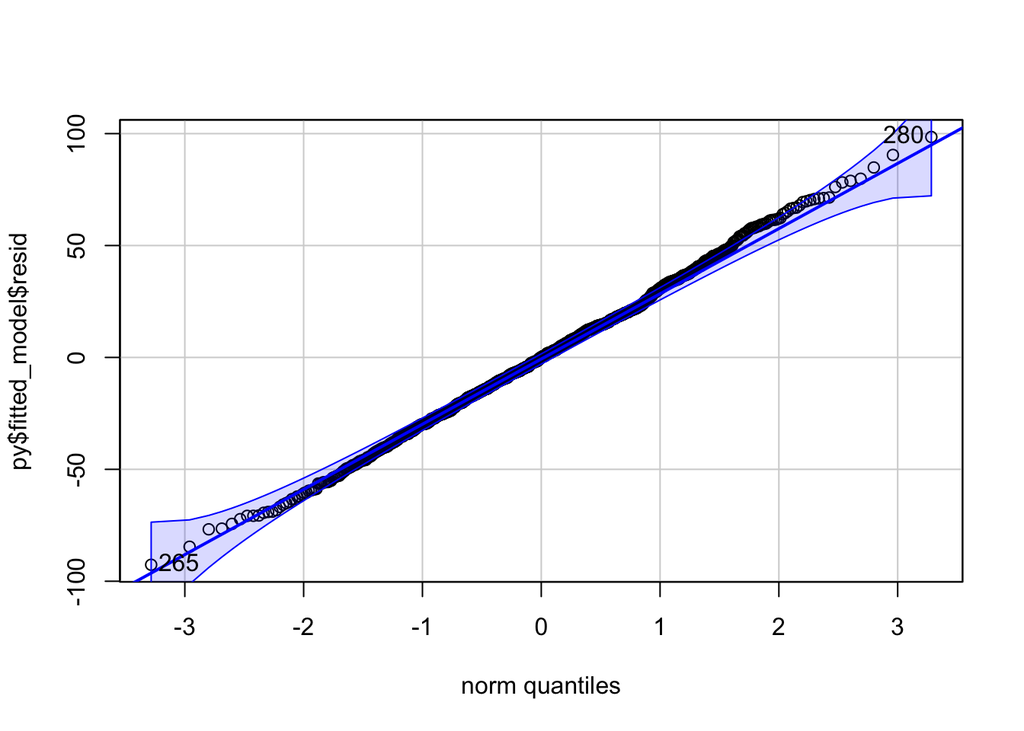

```
## 280 265
## 281 266
```

```r
qqPlot(py$fitted_model$resid)
```

# 3. Segundo ejemplo

Supongamos ahora que se han estado analizando algunos datos en Python y se ha creado un `dataframe` de **pandas** con todos ellos. Vamos a descargar los datos y echarles un vistazo:

```python
import pandas as pd

url = "http://peopleanalytics-regression-book.org/data/speed_dating.csv"
speed_dating = pd.read_csv(url)
print(speed_dating.head())
```

```
##    iid  gender  match  samerace  race  goal  dec  attr  intel  prob  agediff
## 0    1       0      0         0   4.0   2.0    1   6.0    7.0   6.0      6.0
## 1    1       0      0         0   4.0   2.0    1   7.0    7.0   5.0      1.0
## 2    1       0      1         1   4.0   2.0    1   5.0    9.0   NaN      1.0
## 3    1       0      1         0   4.0   2.0    1   7.0    8.0   6.0      2.0
## 4    1       0      1         0   4.0   2.0    1   5.0    7.0   6.0      3.0
```

Supongamos que has ejecutado un *modelo de regresión logística simple* en Python para intentar relacionar la decisión `dec` con algunas de las otras variables.

```python
import pandas as pd
import statsmodels.api as sm
import statsmodels.formula.api as smf

# Datos
url = "http://peopleanalytics-regression-book.org/data/speed_dating.csv"
speed_dating = pd.read_csv(url)

# Modelo
model = smf.glm(formula = "dec ~ agediff + samerace + attr + intel + prob",
                data = speed_dating,
                family = sm.families.Binomial())

# Estimación del modelo
promotion_model = model.fit()

# Resultados
print(promotion_model.summary())
```

```
##                  Generalized Linear Model Regression Results
## ==============================================================================
## Dep. Variable:                    dec   No. Observations:                 7789
## Model:                            GLM   Df Residuals:                     7783
## Model Family:                Binomial   Df Model:                            5
## Link Function:                  logit   Scale:                          1.0000
## Method:                          IRLS   Log-Likelihood:                -4041.5
## Date:                vie, 10 sep 2021   Deviance:                       8082.9
## Time:                        07:39:37   Pearson chi2:                 8.04e+03
## No. Iterations:                     5
## Covariance Type:            nonrobust
## ==============================================================================
##                  coef    std err          z      P>|z|      [0.025      0.975]
## ------------------------------------------------------------------------------
## Intercept     -5.8129      0.184    -31.534      0.000      -6.174      -5.452
## agediff       -0.0105      0.009     -1.165      0.244      -0.028       0.007
## samerace      -0.0934      0.056     -1.677      0.094      -0.203       0.016
## attr           0.6611      0.019     34.111      0.000       0.623       0.699
## intel         -0.0045      0.021     -0.216      0.829      -0.045       0.036
## prob           0.2706      0.015     18.575      0.000       0.242       0.299
## ==============================================================================
```

Sin embargo, te das cuenta de que estos datos son en realidad jerárquicos ya que el mismo `iid` individual puede tener múltiples fechas, así que es necesario estimar un *modelo de regresión logística de efectos mixtos*, ¡pero no puedes encontrar ningún programa en Python que lo haga! Sin problema, se lo mandas a un colega para que lo estime en R:

```r
library(lme4)
speed_dating <- py$speed_dating

iid_intercept_model <- lme4:::glmer(dec ~ agediff + samerace + attr + intel + prob + (1 | iid), data = speed_dating, family = "binomial")
summary(iid_intercept_model)
```

```
## Generalized linear mixed model fit by maximum likelihood (Laplace
##   Approximation) [glmerMod]
##  Family: binomial  ( logit )
## Formula: dec ~ agediff + samerace + attr + intel + prob + (1 | iid)
##    Data: speed_dating
##
##      AIC      BIC   logLik deviance df.resid
##   6420.3   6469.0  -3203.1   6406.3     7782
##
## Scaled residuals:
##      Min       1Q   Median       3Q      Max
## -25.6968  -0.3644  -0.0606   0.3608  25.0370
##
## Random effects:
##  Groups Name        Variance Std.Dev.
##  iid    (Intercept) 5.18     2.276
## Number of obs: 7789, groups:  iid, 541
##
## Fixed effects:
##              Estimate Std. Error z value Pr(>|z|)
## (Intercept) -12.88885    0.42149 -30.579  < 2e-16 ***
## agediff      -0.03671    0.01401  -2.621  0.00877 **
## samerace      0.20186    0.08140   2.480  0.01314 *
## attr          1.07895    0.03334  32.361  < 2e-16 ***
## intel         0.31592    0.03473   9.097  < 2e-16 ***
## prob          0.61998    0.02873  21.580  < 2e-16 ***
## ---
## Signif. codes:  0 '***' 0.001 '**' 0.01 '*' 0.05 '.' 0.1 ' ' 1
##
## Correlation of Fixed Effects:
##          (Intr) agedff samerc attr   intel
## agediff  -0.098
## samerace -0.103 -0.048
## attr     -0.646  0.003  0.008
## intel    -0.641 -0.030  0.055  0.049
## prob     -0.502 -0.003 -0.025  0.266 -0.008
```

```r
coefficients <- coef(iid_intercept_model)$iid
```

Ahora se pueden recuperar los resultados en Python y echar un vistazo a las estimaciones de los coeficientes, por ejemplo. Para acceder a los objetos de R en Python se utiliza el objeto de lista general `r`.

```python
coefs = r.coefficients
print(coefs.head())
```

```
##    (Intercept)  agediff  samerace      attr    intel      prob
## 1   -10.573307 -0.03671  0.201863  1.078946  0.31592  0.619976
## 2   -13.612416 -0.03671  0.201863  1.078946  0.31592  0.619976
## 3   -18.188261 -0.03671  0.201863  1.078946  0.31592  0.619976
## 4   -14.473331 -0.03671  0.201863  1.078946  0.31592  0.619976
## 5   -10.893444 -0.03671  0.201863  1.078946  0.31592  0.619976
```